# Uso de API de Covid19 con Pandas

- https://covid19api.com/
- https://api.covid19api.com/

## Instalación Pandas

En primer lugar, en esta actividad dirigida dónde hicimos uso de la [API de Covid-19](https://covid19api.com/#subscribe) para consultar información sobre los avances de la pandemia de la COVID-19, instalamos Pandas, la cual pemite leer y escribir datos en formatos como CSV, Excel, HDF5, entre otros; así como seleccionar y filtrar tablas de datos.

```python
!pip install pandas
```

## Configuración

Utilizamos `import pandas as pd` para importar la biblioteca de análisis de pandas a python, entorno dónde se está realizando la actividad. A su vez, también le pide que denomine el alias de `pd`, el cual será utilizado más adelante en otras funciones.

```python
import pandas as pd
```

## Variables

Este es un paso muy importante pues aquí es donde se define la URL de la que se desea extraer los datos. En este caso fue [API COUNTRIES](https://api.covid19api.com/countries)

```python
url = 'https://api.covid19api.com/countries'
```

```python
url
```

```
'https://api.covid19api.com/countries'
```

## Creación de *Dataframe*

utilizamos la función `red_json` de *pandas* para leer los datos en JSON de la API:

El dataframe es una estructura fundamental para manipular conjuntos de datos. En ese sentido, en este punto se conectaron los datos del API para extraerlos en ese repositorio. Se creó el dataframe con la función `df = pd.read_json(url)`, la cual también sirve para leer los datos en JSON de la API.

```python
df = pd.read_json(url)
```

```python
df
```

|  | Country | Slug | ISO2 |
| --- | --- | --- | --- |
| 0 | Republic of Kosovo | kosovo | XK |
| 1 | Botswana | botswana | BW |
| 2 | Central African Republic | central-african-republic | CF |
| 3 | Hungary | hungary | HU |
| 4 | Peru | peru | PE |
| ... | ... | ... | ... |
| 243 | Malta | malta | MT |
| 244 | San Marino | san-marino | SM |
| 245 | Gibraltar | gibraltar | GI |
| 246 | Uganda | uganda | UG |
| 247 | Vanuatu | vanuatu | VU |

248 rows × 3 columns

## Explorar tabla

- Cabecera
- Cola
- Descripción

Con el código `df.tail ()` podemos explorar los datos de la tabla que ya hemos creado. En el paréntesis se puede definir el número en concreto de la fila que queremos visualizar, mientras que, si el paréntesis se queda vacío, el programa dará a conocer los cinco primeros o últimos valores, dependiendo de si se define como cabecera `head` o cola `tail`.

```python
df.head ()
```

|  | Country | Slug | ISO2 |
| --- | --- | --- | --- |
| 0 | Republic of Kosovo | kosovo | XK |
| 1 | Botswana | botswana | BW |
| 2 | Central African Republic | central-african-republic | CF |
| 3 | Hungary | hungary | HU |
| 4 | Peru | peru | PE |

```python
df.tail ()
```

|  | Country | Slug | ISO2 |
| --- | --- | --- | --- |
| 243 | Malta | malta | MT |
| 244 | San Marino | san-marino | SM |
| 245 | Gibraltar | gibraltar | GI |
| 246 | Uganda | uganda | UG |
| 247 | Vanuatu | vanuatu | VU |

Entre tanto, con la función `df.describe()` se realizó una descripción númerica de la tabla y con el código `df.info()`, se pudo consultar un resumen del dataframe con el fin de conocer si hay o no celdas vacías en esta tabla.

```python
df.describe()
```

|  | Country | Slug | ISO2 |
| --- | --- | --- | --- |
| count | 248 | 248 | 248 |
| unique | 248 | 248 | 248 |
| top | Guyana | colombia | RU |
| freq | 1 | 1 | 1 |

```python
df.info ()
```

```
<class 'pandas.core.frame.DataFrame'>
RangeIndex: 248 entries, 0 to 247
Data columns (total 3 columns):
 #   Column   Non-Null Count  Dtype
---  ------   --------------  -----
 0   Country  248 non-null    object
 1   Slug     248 non-null    object
 2   ISO2     248 non-null    object
dtypes: object(3)
memory usage: 5.9+ KB
```

## Acceso a datos

En este apartado, seleccionamos los datos que queríamos observar, es decir, entre corchetes definimos que analizaríamos los países con el código `df['Country']`. Después, se visualizaron los primeros y últimos cinco países que figuran en la lista, así como la cantidad de naciones que se encuentran en esos datos, en este caso son 248 en total.

```python
df['Country']
```

```
0            Republic of Kosovo
1                      Botswana
2      Central African Republic
3                       Hungary
4                          Peru
                 ...
243                       Malta
244                  San Marino
245                   Gibraltar
246                      Uganda
247                     Vanuatu
Name: Country, Length: 248, dtype: object
```

Después, utilizamos la función `df['Country'][200]`para saber qué país figura en la posición de 200 de la lista. El comando nos dice que es `Angola`.

```python
df['Country'][200]
```

```
'Angola'
```

## Tiempo real España

En este punto se utilizó el código `url_live` para conocer los datos en tiempo real de la url_es = (https://api.covid19api.com/country/spain/status/confirmed/live) y debajo pusimos el data frame para visualizar las cifras correspondientes a España, así como las fechas de los mismos.

```python
url_live = 'https://api.covid19api.com/country/spain/status/confirmed/live'
df_es = pd.read_json(url_live)
df_es
```

|  | Country | CountryCode | Province | City | CityCode | Lat | Lon | Cases | Status | Date |
| --- | --- | --- | --- | --- | --- | --- | --- | --- | --- | --- |
| 0 | Spain | ES |  |  |  | 40.46 | -3.75 | 0 | confirmed | 2020-01-22 00:00:00+00:00 |
| 1 | Spain | ES |  |  |  | 40.46 | -3.75 | 0 | confirmed | 2020-01-23 00:00:00+00:00 |
| 2 | Spain | ES |  |  |  | 40.46 | -3.75 | 0 | confirmed | 2020-01-24 00:00:00+00:00 |
| 3 | Spain | ES |  |  |  | 40.46 | -3.75 | 0 | confirmed | 2020-01-25 00:00:00+00:00 |
| 4 | Spain | ES |  |  |  | 40.46 | -3.75 | 0 | confirmed | 2020-01-26 00:00:00+00:00 |
| ... | ... | ... | ... | ... | ... | ... | ... | ... | ... | ... |
| 794 | Spain | ES |  |  |  | 40.46 | -3.75 | 11451676 | confirmed | 2022-03-26 00:00:00+00:00 |
| 795 | Spain | ES |  |  |  | 40.46 | -3.75 | 11451676 | confirmed | 2022-03-27 00:00:00+00:00 |
| 796 | Spain | ES |  |  |  | 40.46 | -3.75 | 11451676 | confirmed | 2022-03-28 00:00:00+00:00 |
| 797 | Spain | ES |  |  |  | 40.46 | -3.75 | 11508309 | confirmed | 2022-03-29 00:00:00+00:00 |
| 798 | Spain | ES |  |  |  | 40.46 | -3.75 | 11508309 | confirmed | 2022-03-30 00:00:00+00:00 |

799 rows × 10 columns

Después, como lo hicimos en el apartado "Explorar tabla", utilizamos el código `df_es.info`, para conocer la información del data frame y, para hacer un gráfico de línea con los casos COVID en España, convertimos la columna del dato de fecha en la columna del índice a través del código `df_es.set_index('Date')`.

```python
df_es.info()
```

```
<class 'pandas.core.frame.DataFrame'>
RangeIndex: 799 entries, 0 to 798
Data columns (total 10 columns):
 #   Column       Non-Null Count  Dtype
---  ------       --------------  -----
 0   Country      799 non-null    object
 1   CountryCode  799 non-null    object
 2   Province     799 non-null    object
 3   City         799 non-null    object
 4   CityCode     799 non-null    object
 5   Lat          799 non-null    float64
 6   Lon          799 non-null    float64
 7   Cases        799 non-null    int64
 8   Status       799 non-null    object
 9   Date         799 non-null    datetime64[ns, UTC]
dtypes: datetime64[ns, UTC](1), float64(2), int64(1), object(6)
memory usage: 62.5+ KB
```

```python
df_es.set_index('Date')
```

| Date | Country | CountryCode | Province | City | CityCode | Lat | Lon | Cases | Status |
| --- | --- | --- | --- | --- | --- | --- | --- | --- | --- |
| 2020-01-22 00:00:00+00:00 | Spain | ES |  |  |  | 40.46 | -3.75 | 0 | confirmed |
| 2020-01-23 00:00:00+00:00 | Spain | ES |  |  |  | 40.46 | -3.75 | 0 | confirmed |
| 2020-01-24 00:00:00+00:00 | Spain | ES |  |  |  | 40.46 | -3.75 | 0 | confirmed |
| 2020-01-25 00:00:00+00:00 | Spain | ES |  |  |  | 40.46 | -3.75 | 0 | confirmed |
| 2020-01-26 00:00:00+00:00 | Spain | ES |  |  |  | 40.46 | -3.75 | 0 | confirmed |
| ... | ... | ... | ... | ... | ... | ... | ... | ... | ... |
| 2022-03-26 00:00:00+00:00 | Spain | ES |  |  |  | 40.46 | -3.75 | 11451676 | confirmed |
| 2022-03-27 00:00:00+00:00 | Spain | ES |  |  |  | 40.46 | -3.75 | 11451676 | confirmed |
| 2022-03-28 00:00:00+00:00 | Spain | ES |  |  |  | 40.46 | -3.75 | 11451676 | confirmed |
| 2022-03-29 00:00:00+00:00 | Spain | ES |  |  |  | 40.46 | -3.75 | 11508309 | confirmed |
| 2022-03-30 00:00:00+00:00 | Spain | ES |  |  |  | 40.46 | -3.75 | 11508309 | confirmed |

799 rows × 9 columns

Posteriormente, definimos un orden específico, en este caso, que comenzará con los valores de fecha y luego con casos. Para ello, empleamos primero la palabra "Date" entre parentésis y luego, entre corchetes, la palabra "Cases". La función quedó de la siguiente manera: `df_es.set_index('Date')['Cases']`

```python
df_es.set_index('Date')['Cases']
```

```
Date
2020-01-22 00:00:00+00:00           0
2020-01-23 00:00:00+00:00           0
2020-01-24 00:00:00+00:00           0
2020-01-25 00:00:00+00:00           0
2020-01-26 00:00:00+00:00           0
                               ...
2022-03-26 00:00:00+00:00    11451676
2022-03-27 00:00:00+00:00    11451676
2022-03-28 00:00:00+00:00    11451676
2022-03-29 00:00:00+00:00    11508309
2022-03-30 00:00:00+00:00    11508309
Name: Cases, Length: 799, dtype: int64
```

Para crear un gráfico de línea con estos datos, se ha utilizado la función `plot`, para mostrar los casos de la COVID-19 en España. El código utilizado fue: `df_es.set_index('Date')['Cases'].plot()`y, finalmente, para darle nombre a esta imágen, se puso entre el paréntesis posterior a la función `plot` (title="Casos de Covid-19 en España")

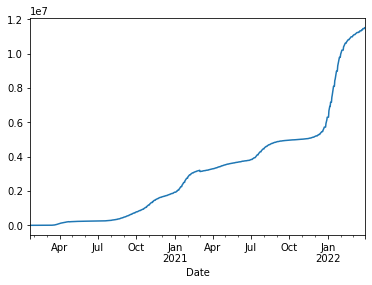

```python
df_es.set_index('Date')['Cases'].plot()
```

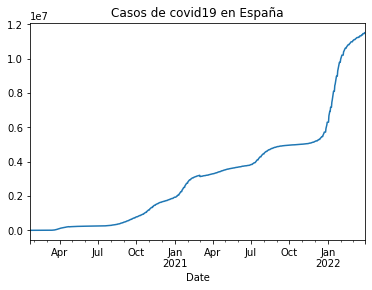

```python
df_es.set_index('Date')['Cases'].plot(title='Casos de covid19 en España')
```

## Tiempo real Colombia

En ese apartado, utilizamos el código `url_live` para conocer los datos en tiempo real de la url_co = (https://api.covid19api.com/country/colombia/status/confirmed/live). Como se ve, en el punto anterior usamos la variable `es` y en esta la variable `co`, para así diferenciar ambos países.

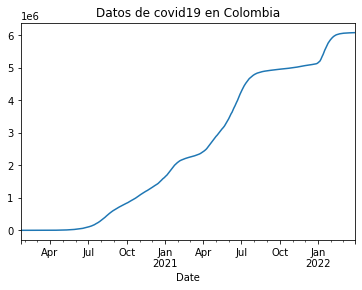

```python
url_co = 'https://api.covid19api.com/country/colombia/status/confirmed/live'
df_co = pd.read_json(url_co)
df_co.set_index('Date')['Cases'].plot(title='Datos de covid19 en Colombia')
```

## Comparativa España-Colombia

Con las funciones `casos_es = df_es.set_index('Date')['Cases']` y `casos_co = df_co.set_index('Date')['Cases']`, se busca comparar los datos de ambos países en forma de gráfico. Después, se utilizó el código `pd.concat([casos_es,casos_co],axis=1)`, con el cual definimos que los casos de España y de Colombia tengan su propia columna en el dataframe con sus respectivos valores.

```python
casos_es = df_es.set_index('Date')['Cases']
casos_co = df_co.set_index('Date')['Cases']
```

```python
pd.concat([casos_es,casos_co],axis=1)
```

| Date | Cases | Cases |
| --- | --- | --- |
| 2020-01-22 00:00:00+00:00 | 0 | 0 |
| 2020-01-23 00:00:00+00:00 | 0 | 0 |
| 2020-01-24 00:00:00+00:00 | 0 | 0 |
| 2020-01-25 00:00:00+00:00 | 0 | 0 |
| 2020-01-26 00:00:00+00:00 | 0 | 0 |
| ... | ... | ... |
| 2022-03-26 00:00:00+00:00 | 11451676 | 6083291 |
| 2022-03-27 00:00:00+00:00 | 11451676 | 6083643 |
| 2022-03-28 00:00:00+00:00 | 11451676 | 6083939 |
| 2022-03-29 00:00:00+00:00 | 11508309 | 6084240 |
| 2022-03-30 00:00:00+00:00 | 11508309 | 6084551 |

799 rows × 2 columns

Posteriormente, se define a `vs` como España y Colombia, pasa así no tener que poner la fórmula completa y se ejecute de manera correcta al usar la función `vs`

```python
vs = pd.concat([casos_es,casos_co],axis=1)
vs
```

| Date | Cases | Cases |
| --- | --- | --- |
| 2020-01-22 00:00:00+00:00 | 0 | 0 |
| 2020-01-23 00:00:00+00:00 | 0 | 0 |
| 2020-01-24 00:00:00+00:00 | 0 | 0 |
| 2020-01-25 00:00:00+00:00 | 0 | 0 |
| 2020-01-26 00:00:00+00:00 | 0 | 0 |
| ... | ... | ... |
| 2022-03-26 00:00:00+00:00 | 11451676 | 6083291 |
| 2022-03-27 00:00:00+00:00 | 11451676 | 6083643 |
| 2022-03-28 00:00:00+00:00 | 11451676 | 6083939 |
| 2022-03-29 00:00:00+00:00 | 11508309 | 6084240 |
| 2022-03-30 00:00:00+00:00 | 11508309 | 6084551 |

799 rows × 2 columns

```python
vs.columns=['España','Colombia']
vs
```

| Date | España | Colombia |
| --- | --- | --- |
| 2020-01-22 00:00:00+00:00 | 0 | 0 |
| 2020-01-23 00:00:00+00:00 | 0 | 0 |
| 2020-01-24 00:00:00+00:00 | 0 | 0 |
| 2020-01-25 00:00:00+00:00 | 0 | 0 |
| 2020-01-26 00:00:00+00:00 | 0 | 0 |
| ... | ... | ... |
| 2022-03-26 00:00:00+00:00 | 11451676 | 6083291 |
| 2022-03-27 00:00:00+00:00 | 11451676 | 6083643 |
| 2022-03-28 00:00:00+00:00 | 11451676 | 6083939 |
| 2022-03-29 00:00:00+00:00 | 11508309 | 6084240 |
| 2022-03-30 00:00:00+00:00 | 11508309 | 6084551 |

799 rows × 2 columns

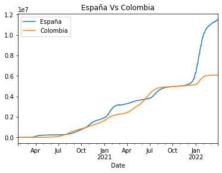

```python
vs.plot(title='España Vs Colombia')
```

## Triple comparativa España-Colombia-Angola

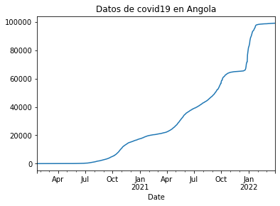

```python
url_ag = 'https://api.covid19api.com/country/angola/status/confirmed/live'
df_ag = pd.read_json(url_ag)
df_ag.set_index('Date')['Cases'].plot(title='Datos de covid19 en Angola')
```

```python
casos_es = df_es.set_index('Date')['Cases']
casos_co = df_co.set_index('Date')['Cases']
casos_ag = df_es.set_index('Date')['Cases']
```

```python
pd.concat([casos_es,casos_co,casos_ag],axis=1)
```

| Date | Cases | Cases | Cases |
| --- | --- | --- | --- |
| 2020-01-22 00:00:00+00:00 | 0 | 0 | 0 |
| 2020-01-23 00:00:00+00:00 | 0 | 0 | 0 |
| 2020-01-24 00:00:00+00:00 | 0 | 0 | 0 |
| 2020-01-25 00:00:00+00:00 | 0 | 0 | 0 |
| 2020-01-26 00:00:00+00:00 | 0 | 0 | 0 |
| ... | ... | ... | ... |
| 2022-03-26 00:00:00+00:00 | 11451676 | 6083291 | 11451676 |
| 2022-03-27 00:00:00+00:00 | 11451676 | 6083643 | 11451676 |
| 2022-03-28 00:00:00+00:00 | 11451676 | 6083939 | 11451676 |
| 2022-03-29 00:00:00+00:00 | 11508309 | 6084240 | 11508309 |
| 2022-03-30 00:00:00+00:00 | 11508309 | 6084551 | 11508309 |

799 rows × 3 columns

```python
vs2= pd.concat([casos_es,casos_co,casos_ag],axis=1)
vs2
```

| Date | Cases | Cases | Cases |
| --- | --- | --- | --- |
| 2020-01-22 00:00:00+00:00 | 0 | 0 | 0 |
| 2020-01-23 00:00:00+00:00 | 0 | 0 | 0 |
| 2020-01-24 00:00:00+00:00 | 0 | 0 | 0 |
| 2020-01-25 00:00:00+00:00 | 0 | 0 | 0 |
| 2020-01-26 00:00:00+00:00 | 0 | 0 | 0 |
| ... | ... | ... | ... |
| 2022-03-26 00:00:00+00:00 | 11451676 | 6083291 | 11451676 |
| 2022-03-27 00:00:00+00:00 | 11451676 | 6083643 | 11451676 |
| 2022-03-28 00:00:00+00:00 | 11451676 | 6083939 | 11451676 |
| 2022-03-29 00:00:00+00:00 | 11508309 | 6084240 | 11508309 |
| 2022-03-30 00:00:00+00:00 | 11508309 | 6084551 | 11508309 |

799 rows × 3 columns

```python
vs2.columns=['España','Colombia','Angola']
vs2
```

[output not shown]

799 rows × 3 columns

[figure not shown]

```python
vs2.plot(title='España, Colombia y Angola')
```

## Seleccionar más columnas

Con la función `df_es.set_index('Date')[['Cases','Lon']]`, se eligió una nueva columna en donde figura los datos de **Longitud**. Utilizados en este ejemplo para visualizar como crear una nueva columna en el dataframe y luego, si es el caso, plasmarlo en un gráfico.

```python
df_es.set_index('Date')[['Cases','Lon']]
```

| Date | Cases | Lon |
| --- | --- | --- |
| 2020-01-22 00:00:00+00:00 | 0 | -3.75 |
| 2020-01-23 00:00:00+00:00 | 0 | -3.75 |
| 2020-01-24 00:00:00+00:00 | 0 | -3.75 |
| 2020-01-25 00:00:00+00:00 | 0 | -3.75 |
| 2020-01-26 00:00:00+00:00 | 0 | -3.75 |
| ... | ... | ... |
| 2022-03-26 00:00:00+00:00 | 11451676 | -3.75 |
| 2022-03-27 00:00:00+00:00 | 11451676 | -3.75 |
| 2022-03-28 00:00:00+00:00 | 11451676 | -3.75 |
| 2022-03-29 00:00:00+00:00 | 11508309 | -3.75 |
| 2022-03-30 00:00:00+00:00 | 11508309 | -3.75 |

799 rows × 2 columns

[figure not shown]

```python
vs.plot(title='España vs Colombia', kind='area')
```

## Exportar datos

Finalmente, se guardaron los datos en CVS, el formato más común de importación y exportación de hojas de cálculo y bases de datos, a tráves del código `vs.to_csv('vs.csv')`. A su vez, estos datos también pueden exportarse como archivo PNG, así como se hizo en la actividad con la función:

```
grafico = vs.plot()
fig = grafico.get_figure()
fig.savefig("vs.png")
```

Este último formato queda guardado en la carpeta que se ha creado para el proyecto.

```python
vs.to_csv('vs.csv')
```

[figure not shown]

```python
grafico = vs.plot()
fig = grafico.get_figure()
fig.savefig("vs.png")
```